# Chapter 7: Exploratory Data Analysis

## 7.5.2.1 Exercises

1. How could you rescale the count dataset above to more clearly show the distribution of cut within colour, or colour within cut?

```r
diamonds %>%
  count(color, cut)
```

```
## Source: local data frame [35 x 3]
## Groups: color [?]
##
##    color       cut     n
##    <ord>     <ord> <int>
## 1      D      Fair   163
## 2      D      Good   662
## 3      D Very Good  1513
## 4      D   Premium  1603
## 5      D     Ideal  2834
## 6      E      Fair   224
## 7      E      Good   933
## 8      E Very Good  2400
## 9      E   Premium  2337
## 10     E     Ideal  3903
## # ... with 25 more rows
```

2. Use geom_tile() together with dplyr to explore how average flight delays vary by destination and month of year. What makes the plot difficult to read? How could you improve it?

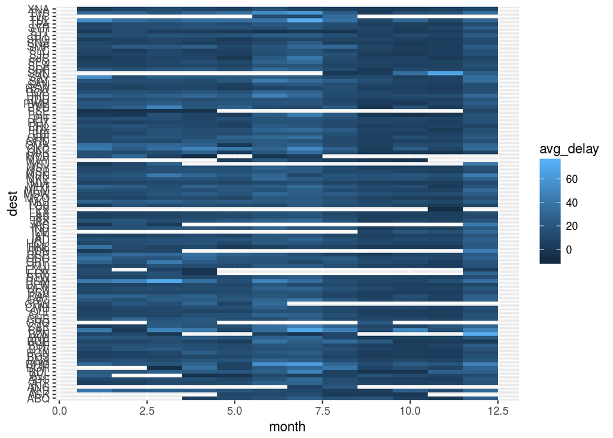

```r
nycflights13::flights %>%
  filter(!is.na(dep_delay)) %>%
  select(month, dest, dep_delay) %>%
  group_by(month, dest) %>%
  summarise(
    avg_delay = mean(dep_delay)
  ) %>%
  ggplot(mapping =aes(x = month, y = dest)) +
    geom_tile(mapping = aes(fill = avg_delay))
```

3. Why is it slightly better to use aes(x = color, y = cut) rather than aes(x = cut, y = color) in the example above?

Two continuous variables

Scatterplot

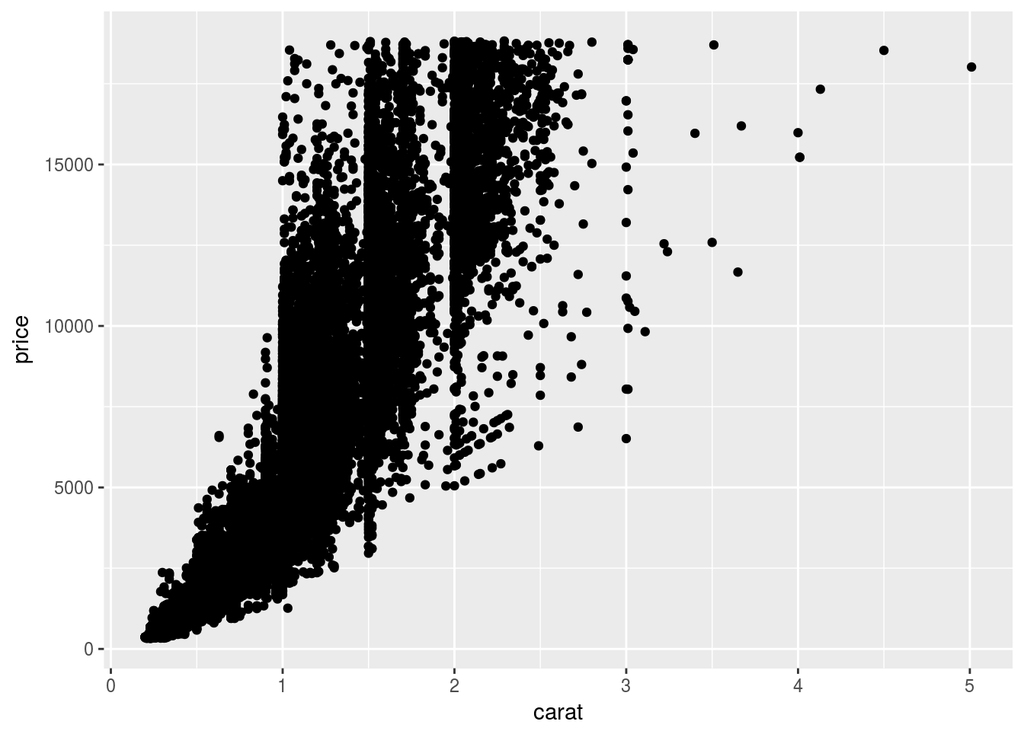

```r
ggplot(data = diamonds) +
  geom_point(mapping = aes(x = carat, y = price))
```

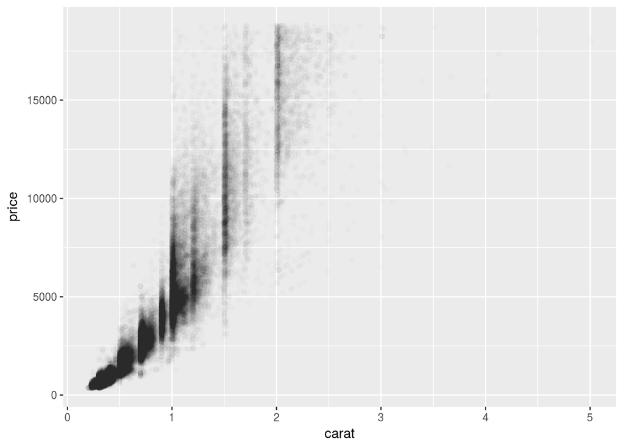

```r
ggplot(data = diamonds) +
  geom_point(mapping = aes(x = carat, y = price), alpha = 1 / 100)
```

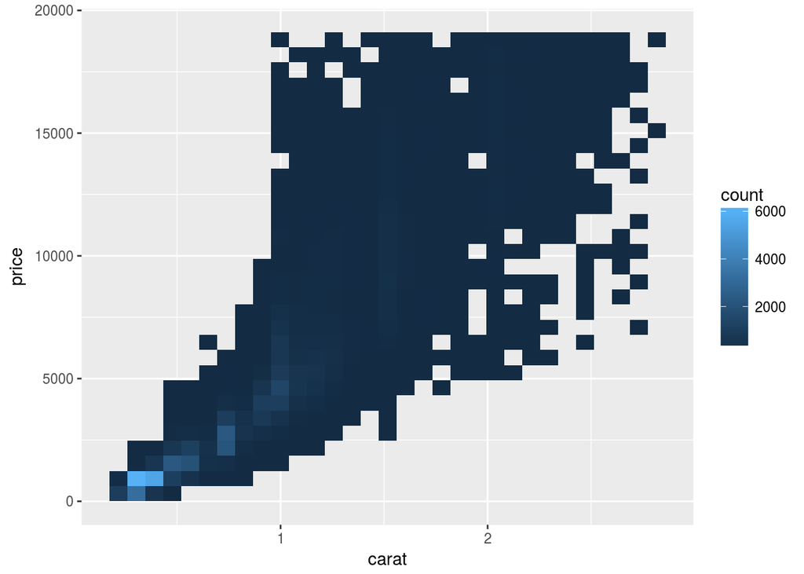

```r
smaller <- diamonds %>%
  filter(carat < 3)
ggplot(data = smaller) +
  geom_bin2d(mapping = aes(x = carat, y = price))
```

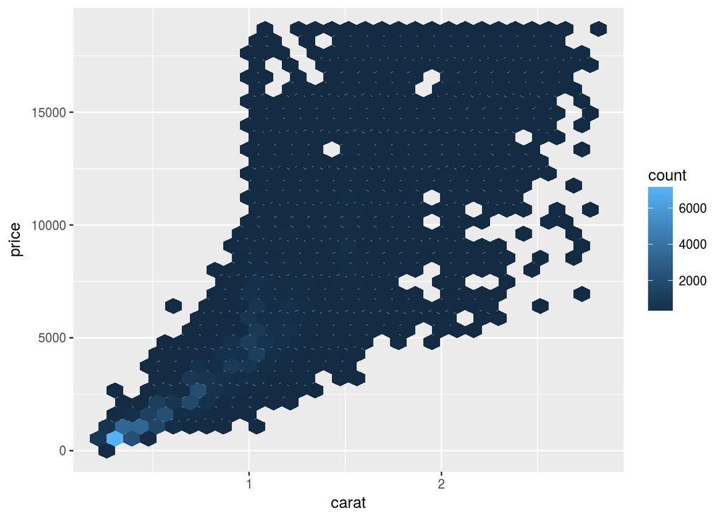

```r
ggplot(data = smaller) +
  geom_hex(mapping = aes(x = carat, y = price))
```

Group a continous variable

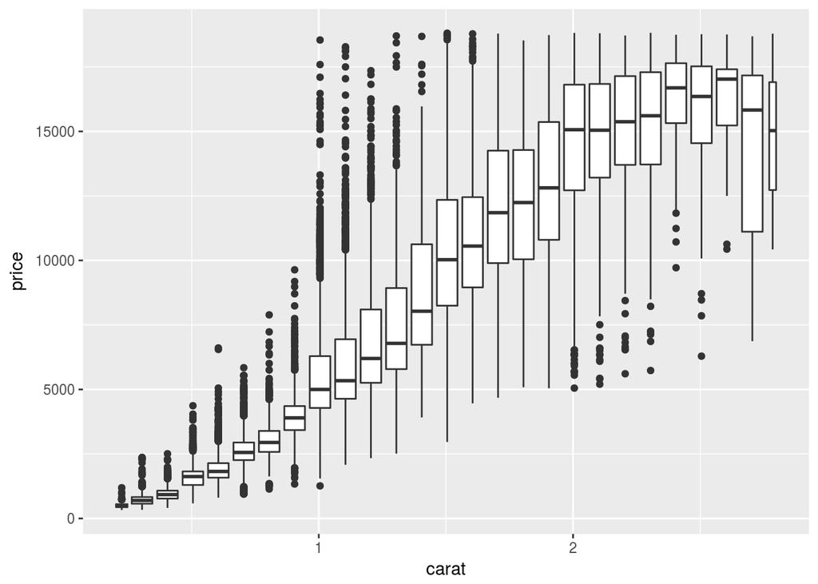

```r
ggplot(data = smaller, mapping = aes(x = carat, y = price)) +
  geom_boxplot(mapping = aes(group = cut_width(carat, 0.1)))
```

Make boxplot width proportional to sqrt of number of observations

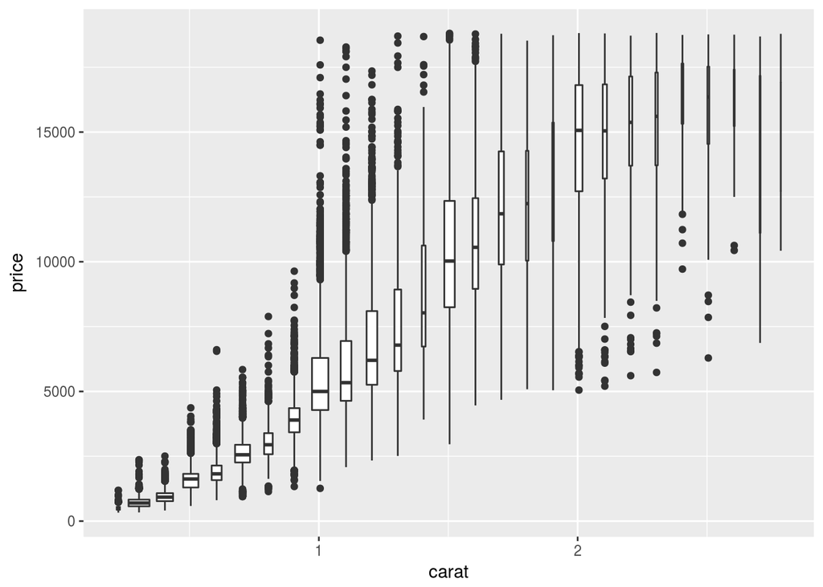

```r
ggplot(data = smaller, mapping = aes(x = carat, y = price)) +
  geom_boxplot(mapping = aes(group = cut_width(carat, 0.1)), varwidth = TRUE)
```

Put equal number of observations in each bin

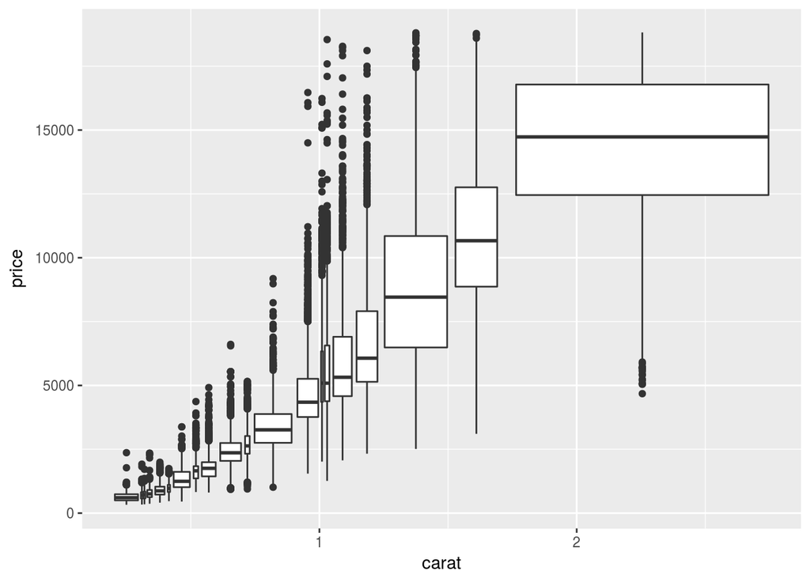

```r
ggplot(data = smaller, mapping = aes(x = carat, y = price)) +
  geom_boxplot(mapping = aes(group = cut_number(carat, 20)))
```

## 7.5.3.1 Exercises

1. Instead of summarising the conditional distribution with a boxplot, you could use a frequency polygon. What do you need to consider when using cut_width() vs cut_number()? How does that impact a visualisation of the 2d distribution of carat and price?

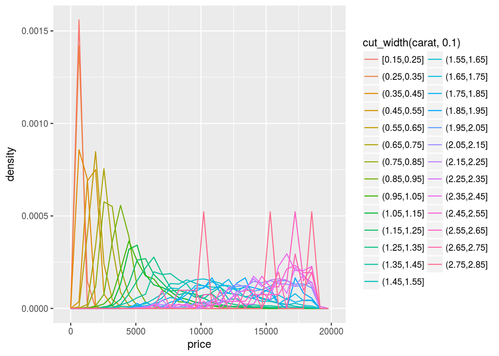

```r
ggplot(data = smaller, mapping = aes(x = price)) +
  geom_freqpoly(mapping = aes(y = ..density.., colour = cut_width(carat, 0.1)))
```

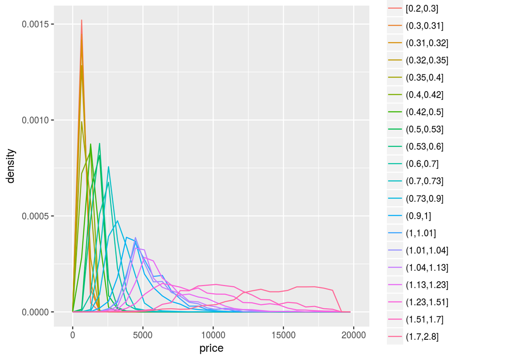

```r
ggplot(data = smaller, mapping = aes(x = price)) +
  geom_freqpoly(mapping = aes(y = ..density.., colour = cut_number(carat, 20)))
```

2. Visualise the distribution of carat, partitioned by price.

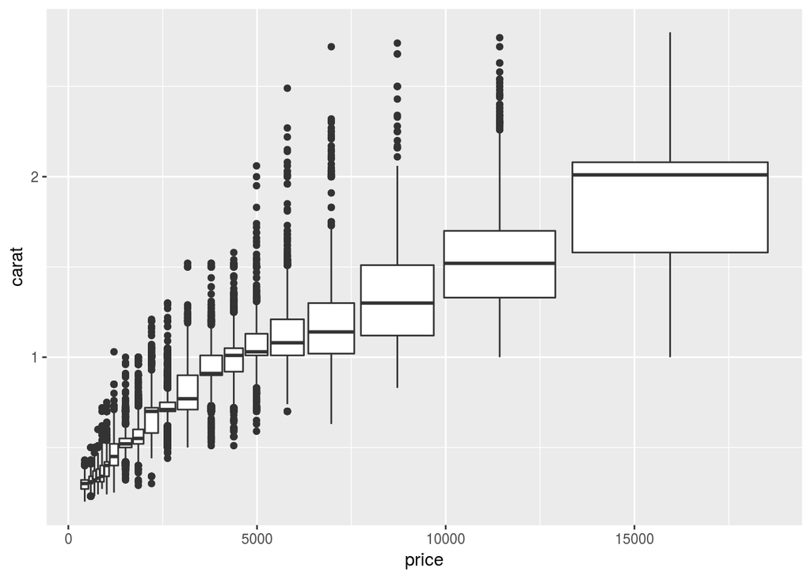

```r
ggplot(data = smaller, mapping = aes(x = price, y = carat)) +
  geom_boxplot(mapping = aes(group = cut_number(price, 20)))
```

3. How does the price distribution of very large diamonds compare to small diamonds. Is it as you expect, or does it surprise you?

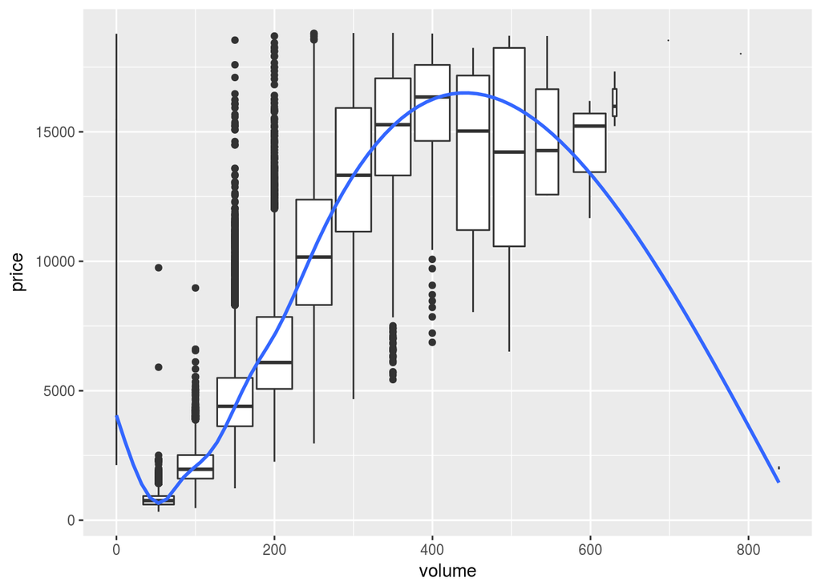

```r
diamonds %>%
  mutate(volume = x * y * z) %>%
  filter(volume < 1000) %>%
  ggplot(mapping = aes(x = volume, y = price)) +
    geom_boxplot(mapping = aes(group = cut_width(volume, 50))) +
    geom_smooth(se = FALSE)
```

4. Combine two of the techniques you’ve learned to visualise the combined distribution of cut, carat, and price.

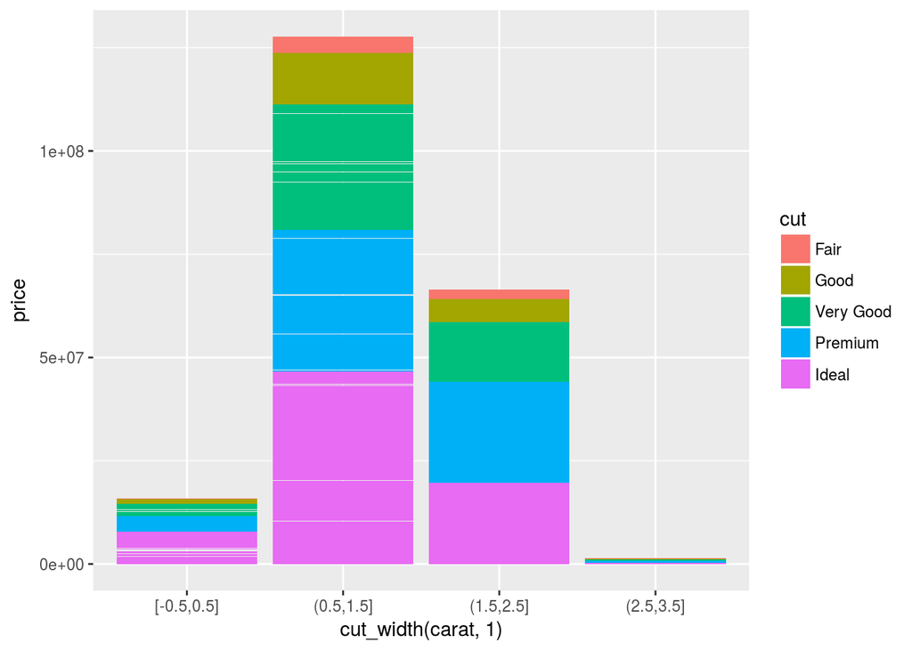

```r
ggplot(data = smaller) +
  geom_bar(mapping = aes(x = cut_width(carat, 1), y = price, fill = cut),
           stat = "identity")
```